# Efficiency of matrix computations

## Example 2.5.4 (Floating-point operations in matrix-vector multiplication)

Here is a straightforward implementation of matrix-vector multiplication.

```python
from numpy import random, ones, zeros
n = 6
A = random.rand(n, n)
x = ones(n)
y = zeros(n)
for i in range(n):
    for j in range(n):
        y[i] += A[i, j] * x[j]   # 2 flops
```

Each of the loops implies a summation of flops. The total flop count for this algorithm is \begin{equation} \sum_{i=1}^{n} \sum_{j=1}^{n} 2 = \sum_{i=1}^{n} 2n = 2n^2. \end{equation}

Since the matrix $\mathbf{A}$ has $n^2$ elements, all of which have to be involved in the product, it seems unlikely that we could get a flop count that is smaller than $\mathcal{O}(n^2)$ in general.

Let’s run an experiment with the built-in matrix-vector multiplication. We assume that flops dominate the computation time and thus measure elapsed time.

```python
from numpy import arange
from time import time as timer
N = 400 * arange(1, 11)
t = []
print("  n           t")
for i, n in enumerate(N):
    A = random.randn(n, n)
    x = random.randn(n)
    start = timer()
    for j in range(50): A @ x
    t.append(timer() - start)
    print(f"{n:5}   {t[-1]:10.3e}")
```

```
  n           t
  400    3.117e-03
  800    1.178e-02
 1200    6.894e-02
 1600    2.078e-01
 2000    4.513e-01
 2400    6.059e-01
 2800    4.267e-01
 3200    3.391e-01
 3600    4.173e-01
 4000    8.564e-01
```

The reason for doing multiple repetitions at each value of $n$ above is to avoid having times so short that the resolution of the timer is a factor.

Looking at the timings just for $n=2000$ and $n=4000$, they have ratio:

```python
print(t[9] / t[4])
```

```
1.8976145850721922
```

If the run time is dominated by flops, then we expect this ratio to be \begin{equation} \frac{2(4000)^2}{2(2000)^2} = 4. \end{equation}

## Example 2.5.5 (Asymptotics in log-log plots)

Suppose that the running time $t$ of an algorithm obeys a function that is $\mathcal{O}(n^p)$. For sufficiently large $n$, $t \approx Cn^p$ for a constant $C$ should be a good approximation. Hence \begin{equation} t \approx Cn^p \quad \Longleftrightarrow \quad \log t \approx p (\log n) + \log C. \end{equation}

So, we expect that a graph of $\log t$ as a function of $\log n$ will be a straight line of slope $p$.

Let’s repeat the experiment of the previous example for more, and larger, values of $n$.

```python
N = arange(400, 6200, 200)
t = zeros(len(N))
for i, n in enumerate(N):
    A = random.randn(n,n)
    x = random.randn(n)
    start = timer()
    for j in range(20): A@x
    t[i] = timer() - start
```

Plotting the time as a function of $n$ on log-log scales is equivalent to plotting the logs of the variables, but is formatted more neatly.

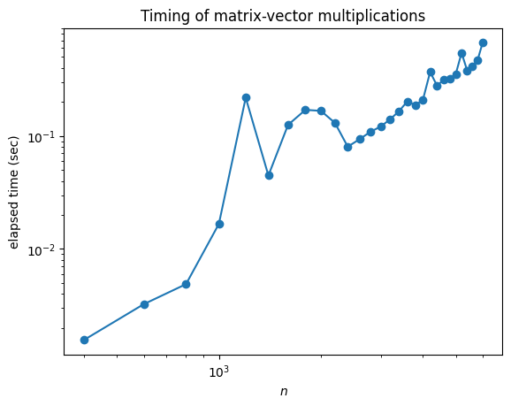

```python
from matplotlib.pyplot import subplots, ylabel, xlabel, title
fig, ax = subplots()
ax.loglog(N, t, "-o", label="observed")
ylabel("elapsed time (sec)");
xlabel("$n$");
title("Timing of matrix-vector multiplications");
```

You can see that while the full story is complicated, the graph is trending to a straight line of positive slope. For comparison, we can plot a line that represents $\mathcal{O}(n^2)$ growth exactly. (All such lines have slope equal to 2.)

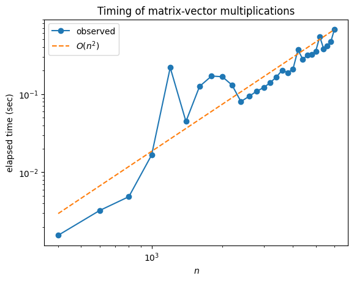

```python
ax.loglog(N, t[-1] * (N/N[-1])**2, "--", label="$O(n^2)$")
ax.legend();  fig
```

## Example 2.5.6 (Floating-point operations in LU factorization)

We'll test the conclusion of $\mathcal{O}(n^3)$ flops experimentally using the $\texttt{lu}$ function imported from $\texttt{scipi.linalg}$.

```python
from scipy.linalg import lu
N = arange(200, 2600, 200)
t = zeros(len(N))
for i, n in enumerate(N):
    A = random.randn(n,n)
    start = timer()
    for j in range(5): lu(A)
    t[i] = timer() - start
```

We plot the timings on a log-log graph and compare it to $\mathcal{O}(n^3)$. The result could vary significantly from machine to machine, but in theory the data should start to parallel the line as $n \to \infty$.

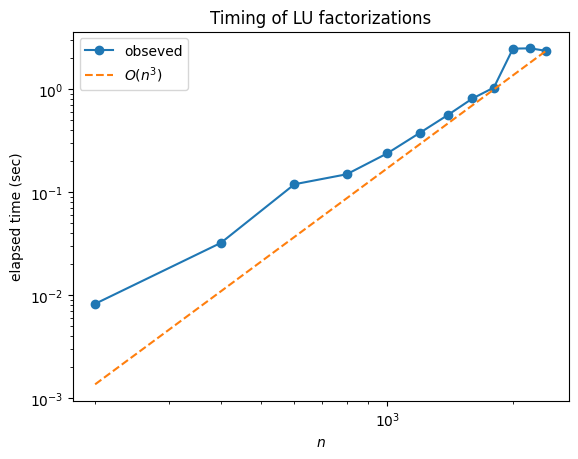

```python
from matplotlib.pyplot import loglog, legend
fig, ax = subplots()
loglog(N, t, "-o", label="obseved")
loglog(N, t[-1] * (N / N[-1])**3, "--", label="$O(n^3)$")
legend();
xlabel("$n$");
ylabel("elapsed time (sec)");
title("Timing of LU factorizations");
```

In practice, flops are not the only aspect of an implementation that occupies significant time. Our position is that counting flops as a measure of performance is a useful oversimplification. We will assume that LU factorization (and as a result, the solution of a linear system of $n$ equations) requires a real-world time that is roughly $\mathcal{O}(n^3)$. This growth rate is a great deal more tolerable than, say, $\mathcal{O}(2^n)$, but it does mean that for (at this writing) $n$ greater than 10,000 or so, something other than general LU factorization will have to be used.

# Row pivoting

## Example 2.6.1 (Failure of naive LU factorization)

Here is a previously encountered matrix that factors well.

```python
def lufact(A):
    """
    lufact(A)

    Compute the LU factorization of square matrix A, returning the
    factors.
    """
    n = A.shape[0]     # detect the dimensions from the input
    L = np.eye(n)      # ones on main diagonal, zeros elsewhere
    U = np.zeros((n, n))
    A_k = np.copy(A.astype(float))    # make a working copy

    # Reduction by np.outer products
    for k in range(n-1):
        U[k, :] = A_k[k, :]
        L[:, k] = A_k[:, k] / U[k,k]
        A_k -= np.outer(L[:,k], U[k,:])
    U[n-1, n-1] = A_k[n-1, n-1]
    return L, U
```

```python
from numpy import array
A = array([
    [2, 0, 4, 3],
    [-4, 5, -7, -10],
    [1, 15, 2, -4.5],
    [-2, 0, 2, -13]
    ])
L, U = lufact(A)
print(L)
```

```
[[ 1.   0.  -0.   0. ]
 [-2.   1.  -0.   0. ]
 [ 0.5  3.   1.   0. ]
 [-1.   0.  -2.   1. ]]
```

If we swap the second and fourth rows of $A$, the result is still nonsingular. However, the factorization now fails.

```python
A[[1, 3], :] = A[[3, 1], :]
L, U = lufact(A)
print(L)
```

```
[[ 1.   nan  nan  0. ]
 [-1.   nan  nan  0. ]
 [ 0.5  inf  nan  0. ]
 [-2.   inf  nan  1. ]]
```

The presence of $NaN$ in the result indicates that some impossible operation was required. The source of the problem is easy to locate. We can find the first outer product in the factorization just fine:

```python
from numpy import outer
U[0, :] = A[0, :]
L[:, 0] = A[:, 0] / U[0, 0]
A -= outer(L[:, 0],  U[0, :])
print(A)
```

```
[[  0.   0.   0.   0.]
 [  0.   0.   6. -10.]
 [  0.  15.   0.  -6.]
 [  0.   5.   1.  -4.]]
```

The next step is $U[1, :] = A[1, :]$, which is also OK. But then we are supposed to divide by $U[1, 1]$, which is zero. The algorithm cannot continue.

## Example 2.6.2 (Row pivoting in LU factorization)

Here is the trouble-making matrix from Example 2.6.1.

```python
A_1 = array([
    [2, 0, 4, 3],
    [-2, 0, 2, -13],
    [1, 15, 2, -4.5],
    [-4, 5, -7, -10]
    ])
```

We now find the largest candidate pivot in the first column. We don’t care about sign, so we take absolute values before finding the max.

```python
from numpy import argmax
i = argmax( abs(A_1[:, 0]) )
print(i)
```

```
3
```

This is the row of the matrix that we extract to put into $U$. That guarantees that the division used to find $ℓ_{1}$ will be valid.

```python
from numpy import eye, zeros
L, U = eye(4), zeros((4, 4))
U[0, :] = A_1[i, :]
L[:, 0] = A_1[:, 0] / U[0, 0]
A_2 = A_1 - outer(L[:, 0], U[0, :])
print(A_2)
```

```
[[ 0.    2.5   0.5  -2.  ]
 [ 0.   -2.5   5.5  -8.  ]
 [ 0.   16.25  0.25 -7.  ]
 [ 0.    0.    0.    0.  ]]
```

Observe that $A_{2}$ has a new zero row and zero column, but the zero row is the fourth rather than the first. However, we forge on by using the largest possible pivot in column 2 for the next outer product.

```python
i = argmax( abs(A_2[:, 1]) )
print(f"new pivot row is {i}")
U[1, :] = A_2[i, :]
L[:, 1] = A_2[:, 1] / U[1, 1]
A_3 = A_2 - outer(L[:, 1], U[1, :])
print(A_3)
```

```
new pivot row is 2
[[ 0.          0.          0.46153846 -0.92307692]
 [ 0.          0.          5.53846154 -9.07692308]
 [ 0.          0.          0.          0.        ]
 [ 0.          0.          0.          0.        ]]
```

Now we have zeroed out the third row as well as the second column. We can finish out the procedure.

```python
i = argmax( abs(A_3[:, 2]) )
print(f"new pivot row is {i}")
U[2, :] = A_3[i, :]
L[:, 2] = A_3[:, 2] / U[2, 2]
A_4 = A_3 - outer(L[:, 2], U[2, :])
print(A_4)
```

```
new pivot row is 1
[[ 0.          0.          0.         -0.16666667]
 [ 0.          0.          0.          0.        ]
 [ 0.          0.          0.          0.        ]
 [ 0.          0.          0.          0.        ]]
```

```python
i = argmax( abs(A_4[:, 3]) )
print(f"new pivot row is {i}")
U[3, :] = A_4[i, :]
L[:, 3] = A_4[:, 3] / U[3, 3];
```

```
new pivot row is 0
```

We do have a factorization of the original matrix:

```python
A_1 - L @ U
```

```
array([[ 0.00000000e+00, -1.38777878e-16,  0.00000000e+00,
         0.00000000e+00],
       [ 0.00000000e+00,  1.38777878e-16,  0.00000000e+00,
         0.00000000e+00],
       [ 0.00000000e+00,  0.00000000e+00,  0.00000000e+00,
         0.00000000e+00],
       [ 0.00000000e+00,  0.00000000e+00,  0.00000000e+00,
         0.00000000e+00]])
```

And $U$ has the required structure:

```python
print(U)
```

```
[[ -4.           5.          -7.         -10.        ]
 [  0.          16.25         0.25        -7.        ]
 [  0.           0.           5.53846154  -9.07692308]
 [  0.           0.           0.          -0.16666667]]
```

However, the triangularity of $L$ has been broken.

```python
print(L)
```

```
[[-0.5         0.15384615  0.08333333  1.        ]
 [ 0.5        -0.15384615  1.         -0.        ]
 [-0.25        1.          0.         -0.        ]
 [ 1.          0.          0.         -0.        ]]
```

Example 2.6.3 (Pivoting as row permutation)

Here again is the matrix from Example 2.6.2.

```python
A = array([
    [2, 0, 4, 3],
    [-2, 0, 2, -13],
    [1, 15, 2, -4.5],
    [-4, 5, -7, -10]
    ])
```

As the factorization proceeded, the pivots were selected from rows 4, 3, 2, and finally 1 (with NumPy indices being one less). If we were to put the rows of $A$ into that order, then the algorithm would run exactly like the plain LU factorization from LU factorization.

```python
B = A[[3, 2, 1, 0], :]
L, U = lufact(B);
```

We obtain the same $U$ as before:

```python
print(U)
```

```
[[ -4.           5.          -7.         -10.        ]
 [  0.          16.25         0.25        -7.        ]
 [  0.           0.           5.53846154  -9.07692308]
 [  0.           0.           0.          -0.16666667]]
```

And $L$ has the same rows as before, but arranged into triangular order:

```python
print(L)
```

```
[[ 1.          0.          0.          0.        ]
 [-0.25        1.          0.          0.        ]
 [ 0.5        -0.15384615  1.          0.        ]
 [-0.5         0.15384615  0.08333333  1.        ]]
```

## LU factorization with partial pivoting

```python
def plufact(A):
    """
        plufact(A)

    Compute the PLU factorization of square matrix A, returning the
    triangular factors and a row permutation vector.
    """
    n = A.shape[0]
    L = np.zeros((n, n))
    U = np.zeros((n, n))
    p = np.zeros(n, dtype=int)
    A_k = np.copy(A.astype(float))

    # Reduction by outer products
    for k in range(n):
        p[k] = np.argmax(abs(A_k[:, k]))
        U[k, :] = A_k[p[k], :]
        L[:, k] = A_k[:, k] / U[k, k]
        if k < n-1:
            A_k -= np.outer(L[:, k], U[k, :])
    return L[p, :], U, p
```

## Example 2.6.4(PLU factorization for solving linear systems)

The third output of plufact is the permutation vector we need to apply to $A$.

```python
A = random.randn(4, 4)
L, U, p = plufact(A)
A[p, :] - L @ U   # should be ≈ 0
```

```
array([[ 0.00000000e+00,  0.00000000e+00,  0.00000000e+00,
         0.00000000e+00],
       [ 0.00000000e+00,  0.00000000e+00, -5.55111512e-17,
         0.00000000e+00],
       [ 0.00000000e+00,  1.11022302e-16,  0.00000000e+00,
         0.00000000e+00],
       [ 0.00000000e+00, -1.11022302e-16,  0.00000000e+00,
         0.00000000e+00]])
```

Given a vector $b$, we solve $Ax = b$ by first permuting the entries of $b$ and then proceeding as before.

```python
def forwardsub(L,b):
  """
  forwardsub(L,b)

  Solve the lower-triangular linear system with matrix L and right-hand side
  vector b.
  """
  n = len(b)
  x = np.zeros(n)
  for i in range(n):
    s = L[i,:i] @ x[:i]
    x[i] = ( b[i] - s ) / L[i, i]
  return x
def backsub(U,b):
  """
  backsub(U,b)

  Solve the upper-triangular linear system with matrix U and right-hand side
  vector b.
  """
  n = len(b)
  x = np.zeros(n)
  for i in range(n-1, -1, -1):
    s = U[i, i+1:] @ x[i+1:]
    x[i] = ( b[i] - s ) / U[i, i]
  return x
```

```python
b = random.randn(4)
z = forwardsub(L, b[p])
x = backsub(U, z)
```

A residual check is successful:

```python
b - A @ x
```

```
array([ 0.00000000e+00,  0.00000000e+00, -2.22044605e-16,  0.00000000e+00])
```

## Example 2.6.5 (Built-in PLU factorization)

In $\texttt{linalg.solve}$, the matrix $A$ is PLU-factored, followed by two triangular solves. If we want to do those steps seamlessly, we can use $\texttt{lu\_factor}$ and $\texttt{lu\_solve}$ from $\texttt{scipy.linalg}$.

```python
from scipy.linalg import lu_factor, lu_solve
A = random.randn(500, 500)
b = ones(500)
LU, perm = lu_factor(A)
x = lu_solve((LU, perm), b)
```

Why would we ever bother with this? In Efficiency of matrix computations we showed that the factorization is by far the most costly part of the solution process. A factorization object allows us to do that costly step only once per matrix, but solve with multiple right-hand sides.

```python
import numpy.linalg as linalg

start = timer()
for k in range(50): linalg.solve(A, random.rand(500))
print(f"elapsed time for 50 full solves: {timer() - start}")

start = timer()
LU, perm = lu_factor(A)
for k in range(50): lu_solve((LU, perm), random.rand(500))
print(f"elapsed time for 50 shortcut solves: {timer() - start}")
```

```
elapsed time for 50 full solves: 0.8645732402801514
elapsed time for 50 shortcut solves: 0.01923227310180664
```

## Example 2.6.6(Stability of PLU factorization)

Let \begin{equation} \mathbf{A} = \begin{bmatrix} -\epsilon & 1 \\ 1 & -1 \end{bmatrix}. \end{equation}

If $\epsilon = 0$, LU factorization without pivoting fails for $\mathbf{A}$. But if $\epsilon \neq 0$, we can go without pivoting, at least in principle.

We construct a linear system for this matrix with $\epsilon = 10^{-12}$ and exact solution $[1, 1]$:

```python
ep = 1e-12
A = array([[-ep, 1], [1, -1]])
b = A @ array([1, 1])
```

We can factor the matrix without pivoting and solve for $x$

```python
L, U = lufact(A)
print(backsub( U, forwardsub(L, b) ))
```

```
[0.99997788 1.        ]
```

Note that we have obtained only about 5 accurate digits for $x_1$. We could make the result even more inaccurate by making ϵ even smaller:

```python
ep = 1e-20;
A = array([[-ep, 1], [1, -1]])
b = A @ array([1, 1])
L, U = lufact(A)
print(backsub( U, forwardsub(L, b) ))
```

```
[-0.  1.]
```

This effect is not due to ill conditioning of the problem—a solution with PLU factorization works perfectly:

```python
print(linalg.solve(A, b))
```

```
[1. 1.]
```

# Vector and matrix norms

## Example 2.7.1(Vector norms)

Given the vector $\mathbf{x} = [2, -3, 1, -1]^T$, we have \begin{align*} \|\mathbf{x}\|_2 &= \sqrt{4 + 9 + 1 + 1} = \sqrt{15}, \\ \|\mathbf{x}\|_\infty &= \max\{2, 3, 1, 1\} = 3, \\ \|\mathbf{x}\|_1 &= 2 + 3 + 1 + 1 = 7. \end{align*}

The $\texttt{norm}$ function from $\texttt{numpy.linalg}$ computes vector norms.

```python
from numpy.linalg import norm
x = [2, -3, 1, -1]
twonorm = norm(x) # or norm(x,2)
print(twonorm)
```

```
3.872983346207417
```

```python
from numpy import inf

infnorm = norm(x, inf)
print(infnorm)
```

```
3.0
```

```python
onenorm = norm(x, 1)
print(onenorm)
```

```
7.0
```

## Example 2.7.3 (Matrix norms)

```python
from numpy.linalg import norm
A = array([ [2, 0], [1, -1] ])
```

The default matrix norm is $not$ the 2-norm. Instead, you must provide the 2 explicitly.

```python
print(norm(A, 2))
```

```
2.2882456112707374
```

You can get the 1-norm as well.

```python
print(norm(A, 1))
```

```
3.0
```

The 1-norm is equivalent to

```python
print(max( sum(abs(A), axis=0)) )  # sum down the rows
```

[output not shown]

Similarly, we can get the ∞-norm and check our formula for it.

```python
print(norm(A, inf))
```

```
2.0
```

Here we illustrate the geometric interpretation of the 2-norm. First, we will sample a lot of vectors on the unit circle in $\mathbb{R}^2$.

```python
from numpy import linspace,vstack,pi,cos,sin
theta = linspace(0, 2*pi, 601)
x = vstack([cos(theta), sin(theta)])  # 601 unit columns
```

The linear function $\mathbf{f}(\mathbf{x}) = \mathbf{A}\mathbf{x}$ defines a mapping from $\mathbb{R}^2$ to $\mathbb{R}^2$. We can apply $\mathbf{A}$ to every column of $\mathbf{x}$ simply by using a matrix multiplication.

```python
y = A @ x
```

We plot the unit circle on the left and the image of all mapped vectors on the right:

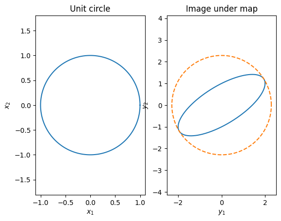

```python
from matplotlib.pyplot import subplot, plot, axis, title, xlabel, ylabel
subplot(1,2,1)
plot(x[0, :], x[1, :])
axis("equal")
title("Unit circle")
xlabel("$x_1$")
ylabel("$x_2$")

subplot(1,2,2)
plot(y[0, :], y[1, :])
plot(norm(A, 2) * x[0, :], norm(A,2) * x[1, :],"--")
axis("equal")
title("Image under map")
xlabel("$y_1$")
ylabel("$y_2$");
```

As seen on the right-side plot, the image of the transformed vectors is an ellipse that just touches the circle of radius $\|\mathbf{A}\|_2$.

# Conditioning of linear systems

## Example 2.8.1 (Matrix condition number)

The function $\texttt{cond}$ from $\texttt{numpy.linalg}$ is used to compute matrix condition numbers. By default, the 2-norm is used. As an example, the family of \textit{Hilbert matrices} is famously badly conditioned. Here is the $6 \times 6$ case.

```python
A = array([
    [1/(i + j + 2) for j in range(6)]
    for i in range(6)
    ])
print(A)
```

```
[[0.5        0.33333333 0.25       0.2        0.16666667 0.14285714]
 [0.33333333 0.25       0.2        0.16666667 0.14285714 0.125     ]
 [0.25       0.2        0.16666667 0.14285714 0.125      0.11111111]
 [0.2        0.16666667 0.14285714 0.125      0.11111111 0.1       ]
 [0.16666667 0.14285714 0.125      0.11111111 0.1        0.09090909]
 [0.14285714 0.125      0.11111111 0.1        0.09090909 0.08333333]]
```

```python
from numpy.linalg import cond
kappa = cond(A)
print(f"kappa is {kappa:.3e}")
```

```
kappa is 5.110e+07
```

Next we engineer a linear system problem to which we know the exact answer.

```python
x_exact = 1.0 + arange(6)
b = A @ x_exact
```

Now we perturb the data randomly with a vector of norm $10^{-12}$.

```python
dA = random.randn(6, 6)
dA = 1e-12 * (dA / norm(dA, 2))
db = random.randn(6)
db = 1e-12 * (db / norm(db, 2))
```

We solve the perturbed problem using built-in pivoted LU and see how the solution was changed.

```python
x = linalg.solve(A + dA, b + db)
dx = x - x_exact
```

Here is the relative error in the solution.

```python
print(f"relative error is {norm(dx) / norm(x_exact):.2e}")
```

```
relative error is 4.29e-06
```

And here are upper bounds predicted using the condition number of the original matrix.

```python
print(f"b_bound: {kappa * 1e-12 / norm(b):.2e}")
print(f"A_bound: {kappa * 1e-12 / norm(A, 2):.2e}")
```

```
b_bound: 6.72e-06
A_bound: 4.57e-05
```

Even if we don’t make any manual perturbations to the data, machine epsilon does when we solve the linear system numerically.

```python
x = linalg.solve(A, b)
print(f"relative error: {norm(x - x_exact) / norm(x_exact):.2e}")
print(f"rounding bound: {kappa / 2**52:.2e}")
```

```
relative error: 8.88e-10
rounding bound: 1.13e-08
```

Because $\kappa \approx 10^8$, it's possible to lose 8 digits of accuracy in the process of passing from $A$ and $b$ to $x$. That's independent of the algorithm; it's inevitable once the data are expressed in double precision.

Larger Hilbert matrices are even more poorly conditioned.

```python
A = array([ [1/(i+j+2) for j in range(14)] for i in range(14) ])
kappa = cond(A)
print(f"kappa is {kappa:.3e}")
```

```
kappa is 2.995e+17
```

Before we compute the solution, note that $\kappa$ exceeds $1/\texttt{eps}$. In principle we therefore might end up with an answer that is completely wrong (i.e., a relative error greater than 100%).

```python
print(f"rounding bound: {kappa / 2**52:.2e}")
```

```
rounding bound: 6.65e+01
```

```python
x_exact = 1.0 + arange(14)
b = A @ x_exact
x = linalg.solve(A, b)
```

We got an answer. But in fact, the error does exceed 100%:

```python
print(f"relative error: {norm(x - x_exact) / norm(x_exact):.2e}")
```

```
relative error: 3.30e+00
```

# Exploiting matrix structure

## Example 2.9.1 (Banded matrices)

Here is a matrix with both lower and upper bandwidth equal to one. Such a matrix is called tridiagonal.

```python
A = array([
    [2, -1,  0,  0,  0,  0],
    [4,  2, -1,  0,  0,  0],
    [0,  3,  0, -1,  0,  0],
    [0,  0,  2,  2, -1,  0],
    [0,  0,  0,  1,  1, -1],
    [0,  0,  0,  0,  0,  2 ]
    ])
```

We can extract the elements on any diagonal using the $\texttt{diag}$ command. The ``main'' or central diagonal is numbered zero, above and to the right of that is positive, and below and to the left is negative.

```python
from  numpy import diag
print( diag(A) )
```

```
[2 2 0 2 1 2]
```

```python
print( diag(A, 1) )
```

```
[-1 -1 -1 -1 -1]
```

```python
print( diag(A, -1) )
```

```
[4 3 2 1 0]
```

We can also construct matrices by specifying a diagonal with the diag function.

```python
A = A + diag([pi, 8, 6, 7], 2)
print(A)
```

```
[[ 2.         -1.          3.14159265  0.          0.          0.        ]
 [ 4.          2.         -1.          8.          0.          0.        ]
 [ 0.          3.          0.         -1.          6.          0.        ]
 [ 0.          0.          2.          2.         -1.          7.        ]
 [ 0.          0.          0.          1.          1.         -1.        ]
 [ 0.          0.          0.          0.          0.          2.        ]]
```

```python
L, U = lufact(A)
print(L)
```

```
[[1.         0.         0.         0.         0.         0.        ]
 [2.         1.         0.         0.         0.         0.        ]
 [0.         0.75       1.         0.         0.         0.        ]
 [0.         0.         0.36614016 1.         0.         0.        ]
 [0.         0.         0.         0.21915497 1.         0.        ]
 [0.         0.         0.         0.         0.         1.        ]]
```

```python
print(U)
```

```
[[ 2.         -1.          3.14159265  0.          0.          0.        ]
 [ 0.          4.         -7.28318531  8.          0.          0.        ]
 [ 0.          0.          5.46238898 -7.          6.          0.        ]
 [ 0.          0.          0.          4.56298115 -3.19684099  7.        ]
 [ 0.          0.          0.          0.          1.70060359 -2.53408479]
 [ 0.          0.          0.          0.          0.          2.        ]]
```

Observe above that the lower and upper bandwidths of $A$ are preserved in the factor matrices.

## Example 2.9.2(Symmetric $LDL^T$factorization)

We begin with a symmetric $A$

```python
A_1 = array([
    [2,     4,     4,     2],
    [4,     5,     8,    -5],
    [4,     8,     6,     2],
    [2,    -5,     2,   -26]
    ])
```

We won’t use pivoting, so the pivot element is at position $(1,1)$. This will become the first element on the diagonal of $\mathbf{D}$. Then we divide by that pivot to get the first column of $\mathbf{L}$.

```python
L = eye(4)
d = zeros(4)
d[0] = A_1[0, 0]
L[:, 0] = A_1[:, 0] / d[0]
A_2 = A_1 - d[0] * outer(L[:, 0], L[:, 0])
print(A_2)
```

```
[[  0.   0.   0.   0.]
 [  0.  -3.   0.  -9.]
 [  0.   0.  -2.  -2.]
 [  0.  -9.  -2. -28.]]
```

We are now set up the same way for the submatrix in rows and columns 2–4.

```python
d[1] = A_2[1, 1]
L[:, 1] = A_2[:, 1] / d[1]
A_3 = A_2 - d[1] * outer(L[:, 1], L[:, 1])
print(A_3)
```

```
[[ 0.  0.  0.  0.]
 [ 0.  0.  0.  0.]
 [ 0.  0. -2. -2.]
 [ 0.  0. -2. -1.]]
```

We continue working our way down the diagonal.

```python
d[2] = A_3[2, 2]
L[:, 2] = A_3[:, 2] / d[2]
A_4 = A_3 - d[2] * outer(L[:, 2], L[:, 2])
print(A_4)
```

```
[[0. 0. 0. 0.]
 [0. 0. 0. 0.]
 [0. 0. 0. 0.]
 [0. 0. 0. 1.]]
```

We have arrived at the desired factorization.

```python
d[3] = A_4[3, 3]
print("diagonal of D:")
print(d)
print("L:")
print(L)
```

```
diagonal of D:
[ 2. -3. -2.  1.]
L:
[[ 1. -0. -0.  0.]
 [ 2.  1. -0.  0.]
 [ 2. -0.  1.  0.]
 [ 1.  3.  1.  1.]]
```

This should be comparable to machine roundoff:

```python
print(norm(A_1 - (L @ diag(d) @ L.T), 2) / norm(A_1))
```

```
0.0
```

## Example 2.9.3(Cholesky factorization)

A randomly chosen matrix is extremely unlikely to be symmetric. However, there is a simple way to symmetrize one.

```python
from numpy import floor
A = 1.0 + floor(9 * random.rand(4, 4))
B = A + A.T
print(B)
```

```
[[ 2. 11. 15. 10.]
 [11.  2. 10.  5.]
 [15. 10. 14. 13.]
 [10.  5. 13. 10.]]
```

Similarly, a random symmetric matrix is unlikely to be positive definite. The Cholesky algorithm always detects a non-PD matrix by quitting with an error.

```python
from numpy.linalg import cholesky
cholesky(B)    # raises an exception, not positive definite
```

```
---------------------------------------------------------------------------
LinAlgError                               Traceback (most recent call last)
/tmp/ipython-input-1938187923.py in <cell line: 0>()
      1 from numpy.linalg import cholesky
----> 2 cholesky(B)    # raises an exception, not positive definite

/usr/local/lib/python3.12/dist-packages/numpy/linalg/_linalg.py in cholesky(a, upper)
    837     with errstate(call=_raise_linalgerror_nonposdef, invalid='call',
    838                   over='ignore', divide='ignore', under='ignore'):
--> 839         r = gufunc(a, signature=signature)
    840     return wrap(r.astype(result_t, copy=False))
    841

/usr/local/lib/python3.12/dist-packages/numpy/linalg/_linalg.py in _raise_linalgerror_nonposdef(err, flag)
    105
    106 def _raise_linalgerror_nonposdef(err, flag):
--> 107     raise LinAlgError("Matrix is not positive definite")
    108
    109 def _raise_linalgerror_eigenvalues_nonconvergence(err, flag):

LinAlgError: Matrix is not positive definite
```

It’s not hard to manufacture an SPD matrix to try out the Cholesky factorization:

```python
B = A.T @ A
R = cholesky(B)
print(R)
```

```
[[10.24695077  0.          0.          0.        ]
 [ 4.19637031  9.02166704  0.          0.        ]
 [ 9.27105069  8.87809733  4.15054295  0.        ]
 [10.14936076  2.26227855  2.60689575  3.32816264]]
```

```python
print(norm(R @ R.T - B) / norm(B))
```

```
5.790052800905036e-17
```